# Part II - PROSPER LOAN DATA SET

## by SAMUEL GICHOBI

## Investigation Overview

> The data wrangling and visualization efforts set to explore the factors that influence the loan status that is the ability of people to take loans, pay them, and also those who fail to pay (defaulters) and those which are charged off (written off) and overdue.

## Dataset Overview

> The data set is on the propser loan data that examines the number of people who have completed their loans or not. The data set contains 113937 columns and 81 rows.The main interest from this dataset is to examine the factors that influence the loan status and if more people currently have loans, defaulted, or paid off their loans.Some of the features that I will consider exploring in this data include LoanStatus, borrowerate, lender yield, ProsperScore, occupation, Term, Employment Status, Employment Status Duration, IsBorrowerHomeowner,Total Credit Lines Past 7 Years, Delinquencies Last 7 Years, Debt to Income Ratio, Income Range, Income Verifiable, Loan Orginal Date, Loan Orginal AMount, Monthly Repayment,

## COUNT OF LOAN STATUS

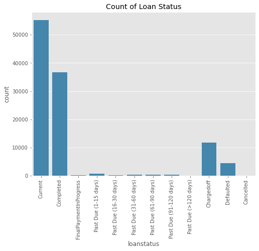

## CORRELATION AMONG NUMERIC VARIABLES (Borrower Rate & Lender Yield Relation)

> The presented heat map reveals positive, negative, and no correlation among numeric variables. It can be observed there exists a strong and positive relationship between the borrower rate and lender yield. A weak negative relationship exists between debt to income ratio and stated monthly income. Therefore, we can conclude that lender's yield directly translate to the borrower rate while a high debt to income ratio has a weak inverse relation to the borrowers monthly income.

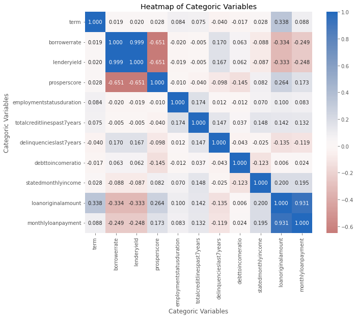

## LOAN STATUS & INCOME RANGE BY LOAN ORIGINAL AMOUNT AND BORROWER RATE

It can be seen that those with a high loan original amount have current loans running while those with lower loans have equally completed their loans and others charged off and defaulted. For those with overdue loans, both borrowers with high original loan amount and low have loans overdue.

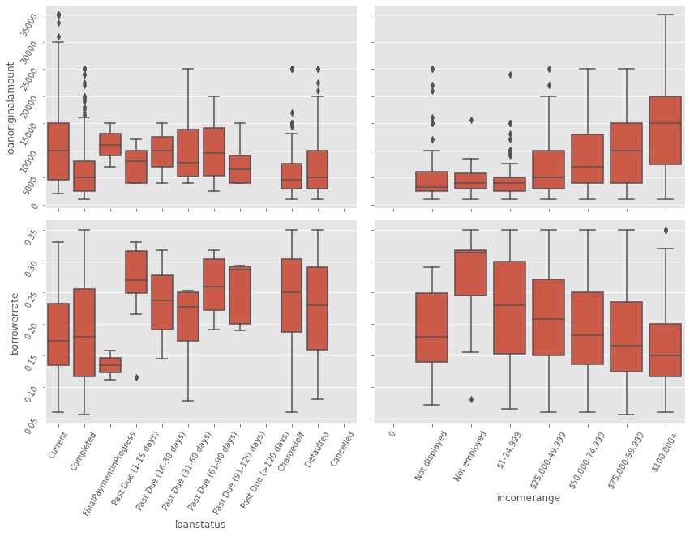

LOAN STATUS BY LOAN ORIGINAL AMOUNT AND MONTHLY LOAN PAYMENT

Borrowers with current loans may pay monthly payment of between 100 and 800 dollars with an exception of few who pay higher monthly payments. A similar linear trend can be obsevered for those who have completed their loans and borrow between 5000 and 25000 pay monthly payments of between 50 and 800 dollars with few paying higher and lower payments. Defaulters and those whose loans struggle to pay high monthly payments and make monthly paymnents of between 100 and 800 dollars. Borrowers with overdue loans pay between 100 and 800 dollars with some exceptions where some people prefer to make higher payments. Therefore, it can be seen that the loan monthly payment depends with the loan original amount with those with higher loans paying more but this is also left to the borrowers discretion as we can see instances where the person borrows less and pays more or borrows more and pays less but these are few.

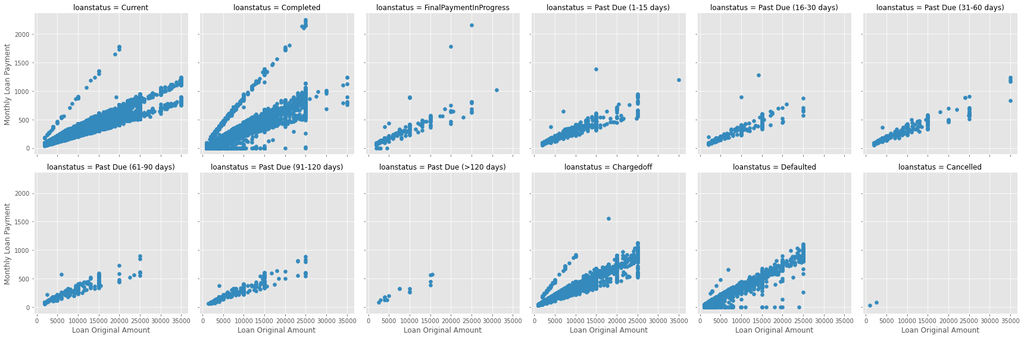

COUNT OF INCOME RANGE & EMPLOYMENT STATUS BY LOAN STATUS AND EMPLOYMENT STATUS

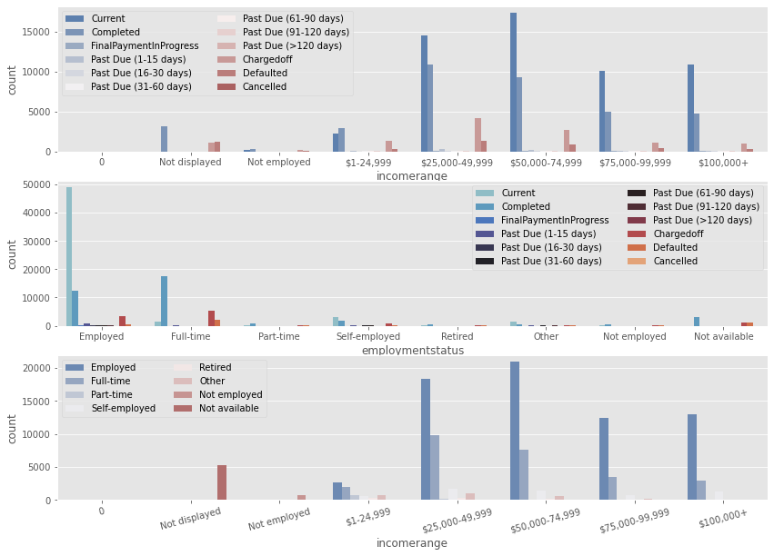